# Valoracion

Grandez

19/4/2021

# Valoracion

De acuerdo como vayamos realizando operaciones de compra/venta, cada una a un precio diferente, necesitaremos un método de valorar correctamente nuestra posicion.

Veamos un ejemplo

[output not shown]

La secuencia de operaciones hasta este momento ha sido:

1. El primer dia *abrimos una posición* comprando 10 unidades de la moneda a un precio de 100
2. Logicamente, el segundo dia tenemos en nuestra cartera 10 unidades que nos ha costado 1.000
3. El tercer dia, la moneda sigue subiendo y volvemos a comprar; otras 10 unidades pero esta vez a un coste de 200, con lo que nos hemos gastado 3000 um.para obtener 20 monedas
4. El cuarto dia, la cotizacion baja, y vendemos 10 monedas para minimizar perdidas.

La pregunta aquí es: ¿Cuanto ha sido de rentable la venta?

1. Si miramos el precio neto, **no hemos ganado ni perdido** nada con respecto a cuando empezamos a operar, seguimos teniendo 10.000 Euros de valoración en nuestra cartera; sin embargo, tenemos 1.000 Euros menos que el día anterior
2. Si asumimos que la venta se corresponde con la última operación de compra realizada (metodo LIFO), hemos **perdido 500 Euros**
3. Si aplicamos la venta a la primera posicion abierta (metodo FIFO) hemos **ganado 500 Euros**

En este momento introducimos el concepto de “*Tomar posición*”:

Ademas de realizar operaciones de compra y de venta introducimos un nuevo tipo de operación; *Abrir posición*.

Esta operación nos “aisla” la compra de la posición global, de manera que, en principio, se comporta como un bloque atómico: Compro una cierta cantidad de monedas (abrir la posición) por algún motivo y en algún momento posterior, vendo esa misma cantidad de monedas (cierro la posición) y el resultado de la operación global únicamente considera los valores de esa operación.

De acuerdo con esto, quitamos la ambigüedad de la valoración; ahora el dia 4 podemos verlo de dos maneras:

| day | quote | Operation id | Operation amount | Operation mov | Position Eur | Position currency | Position cost | Position net | Position value | Position balance |
| --- | --- | --- | --- | --- | --- | --- | --- | --- | --- | --- |
| 4 | 150 | -1 | -10 | -1,500 | 8,500 | 10 | 3,000 | 150 | 1,500 | 10,000 |

| day | quote | Operation id | Operation amount | Operation mov | Position Eur | Position currency | Position cost | Position net | Position value | Position balance |
| --- | --- | --- | --- | --- | --- | --- | --- | --- | --- | --- |
| 4 | 150 | -2 | -10 | -1,500 | 8,500 | 10 | 3,000 | 150 | 1,500 | 10,000 |

Nota: Hemos usado el id negativo para hacer explicita la asociación entre la compra y la venta

- Si hemos optado por deshacer la operación 1, esa operación nos ha reportado un beneficio de 500 Euros
- Si por el contrario optamos por la operación 2, la operación ha sido negativa por un importe de -500 Euros

**¿Cual de las dos opciones tomar?**

Depende del criterio por que el que realizamos las dos operaciones de compra y por el que hicimos la venta. Si por ejemplo, hicimos la segunda operación por que creíamos que la moneda iba a seguir subiendo, parece lógico asumir que nos hemos equivocado y asumir las perdidas.

Si por el contrario, seguimos creyendo que va a seguir subiendo, pero por algún motivo necesitamos capital, parece mas lógico deshacer la primera operación como una operación positiva puesto que esperamos que la moneda vuelva a cotizar por encima de 200.

La decisión de que operación cerrar dependerá únicamente de criterios personales y de los objetivos de cada operación, y esa decisión es la que se utilizará posteriormente para analizar la evolución de la cartera.

## Neteos y splits

Vayamos un paso mas allá.

Sobre el mismo escenario, ahora pensamos que la moneda va a iniciar una caída larga por lo que queremos deshacer todas las posiciones. En este caso se nos plantean algunos problemas:

1. Si cerramos posición por posición, una operación nos aparecerá como fallida y otra como rentable, cuando realmente pensábamos que la moneda se iba a revalorizar y cuando hemos visto el error hemos salido a tiempo con lo que nuestras oepraciones son *neutras* (no hemos ganado ni hemos perdido, solo tiempo y comisiones)
2. Si generamos dos operaciones de venta, cada una de ellas incurrirá en sus comisiones y tasas, aparte de poder cerrarse a diferentes precios; esto puede ser mas costoso que si hacemos una única operación por el total.

Para solventar esto introducimos dos nuevos tipos de operacioens internas: **Net** (Unir) y **Split** (Partir)

### Net

Lo que hacemos con esta operación es agrupar las dos operaciones en una única; veamoslo en la misma tabla introduciendo estos conceptos:

| day | quote | Operation id | Operation type | Operation parent | Operation amount | Operation mov | Position Eur | Position currency | Position cost | Position net | Position value | Position balance |
| --- | --- | --- | --- | --- | --- | --- | --- | --- | --- | --- | --- | --- |
| 0 | 100 |  |  |  |  |  | 10,000 | 0 |  |  |  | 10,000 |
| 1 | 100 | 1 | Open | 0 | 10 | 1,000 | 9,000 | 10 | 1,000 | 100 | 1,000 | 10,000 |
| 2 | 150 |  |  |  |  |  | 9,000 | 10 | 1,000 | 100 | 1,500 | 10,500 |
| 3 | 200 | 2 | Open | 0 | 10 | 2,000 | 7,000 | 20 | 3,000 | 150 | 4,000 | 11,000 |

El dia 4 primero neteamos las dos operaciones

| day | quote | Operation id | Operation type | Operation parent | Operation amount | Operation mov | Position Eur | Position currency | Position cost | Position net | Position value | Position balance |
| --- | --- | --- | --- | --- | --- | --- | --- | --- | --- | --- | --- | --- |
| 0 | 100 |  |  |  |  |  | 10,000 | 0 |  |  |  | 10,000 |
| 1 | 100 | 1 | Open | 3 | 10 | 1,000 | 9,000 | 10 | 1,000 | 100 | 1,000 | 10,000 |
| 2 | 150 |  |  |  |  |  | 9,000 | 10 | 1,000 | 100 | 1,500 | 10,500 |
| 3 | 200 | 2 | Open | 3 | 10 | 2,000 | 7,000 | 20 | 3,000 | 150 | 4,000 | 11,000 |
| 4 | 150 | 3 | Net | 0 | 20 | 3,000 |  |  |  |  |  |  |

Y ahora deshacemos la operación:

| day | quote | Operation id | Operation type | Operation parent | Operation amount | Operation mov | Position Eur | Position currency | Position cost | Position net | Position value | Position balance |
| --- | --- | --- | --- | --- | --- | --- | --- | --- | --- | --- | --- | --- |
| 0 | 100 |  |  |  |  |  | 10,000 | 0 |  |  |  | 10,000 |
| 1 | 100 | 1 | Open | 3 | 10 | 1,000 | 9,000 | 10 | 1,000 | 100 | 1,000 | 10,000 |
| 2 | 150 |  |  |  |  |  | 9,000 | 10 | 1,000 | 100 | 1,500 | 10,500 |
| 3 | 200 | 2 | Open | 3 | 10 | 2,000 | 7,000 | 20 | 3,000 | 150 | 4,000 | 11,000 |
| 4 | 150 | 3 | Net | 4 | 20 | 3,000 |  |  |  |  |  |  |
|  | 150 | 4 | Close | 3 | -20 | -3,000 | 10,000 | 0 | 3,000 | 150 | 0 | 10,000 |

### Split

Si podemos juntar dos operaciones en una, también deberíamos poder dividir una operación en 2. Siguiendo nuestro ejemplo, supongamos que no queremos vender las 20 monedas, si no únicamente 15; esto lo podemos hacer de dos maneras diferentes:

1. Dividimos una de las operaciones en dos (split) y luego *neteamos* una de ellas con la otra operación
2. *Neteamos* las dos operaciones y luego realizamos el *split*

Una vez realizado este proceso, cerramos esa operación

| day | quote | Operation id | Operation type | Operation parent | Operation amount | Operation mov | Position Eur | Position currency | Position cost | Position net | Position value | Position balance |
| --- | --- | --- | --- | --- | --- | --- | --- | --- | --- | --- | --- | --- |
| 0 | 100 |  |  |  |  |  | 10,000 | 0 |  |  |  | 10,000 |
| 1 | 100 | 1 | Open | 3 | 10 | 1,000 | 9,000 | 10 | 1,000 | 100 | 1,000 | 10,000 |
| 2 | 150 |  |  |  |  |  | 9,000 | 10 | 1,000 | 100 | 1,500 | 10,500 |
| 3 | 200 | 2 | Open | 3 | 10 | 2,000 | 7,000 | 20 | 3,000 | 150 | 4,000 | 11,000 |
| 4 | 150 | 3 | Net | 0 | 20 | 3,000 |  |  |  |  |  |  |
|  | 150 | 4 | Split | 3 | 15 | 3,000 |  |  |  |  |  |  |
|  | 150 | 5 | Split | 3 | 5 | 3,000 |  |  |  |  |  |  |
|  | 150 | 6 | Close | 4 | -15 | -2,250 | 10,000 | 5 | 3,000 | 150 | 750 | 10,000 |

### Notas

- Notese que las operaciones de Net y Split son “internas”; es decir, no modifican la posición
- La columna `parent` es la que permite realizar el seguimiento de las operaciones en los dos sentidos:
  - Si es una operación Open, `parent` hace referencia a que tiene “hijos”, un cierre, un neteo o un split
  - Si es otro tipo de operacion, `parent` refiere a su padre

El proceso de seguir esa cadena se realiza de manera programática

# resto

Since R Markdown use the [bootstrap framework](https://getbootstrap.com/docs/4.0/layout/grid/) under the hood. It is possible to benefit its powerful grid system. Basically, you can consider that your row is divided in 12 subunits of same width. You can then choose to use only a few of this subunits.

Introducimos los siguientes conceptos:

[output not shown]

## Regularizacion

Notese que estos valores consideran todas operaciones realiziadas, pero al cabo del tiempo, existiran un conjunto de operaciones de estas operaciones que ya habrán sido descontadas;; es decir, las habremos cargado a “perdidas y ganancias” con lo que ya no deben ser tenidas en cuenta.

Para contemplar esta situación, tipícamente al menos una vez al año, introducimos el concepto de regularización de la posición. Esto no es nada mas que guardar informacion aparte del punto en el tiempo antes del cual no se deben considerar las operaciones, y los saldos en ese momento

## Two columns

Below is a Div containing three child Divs side by side. The Div in the middle is empty, just to add more space between the left and right Divs.

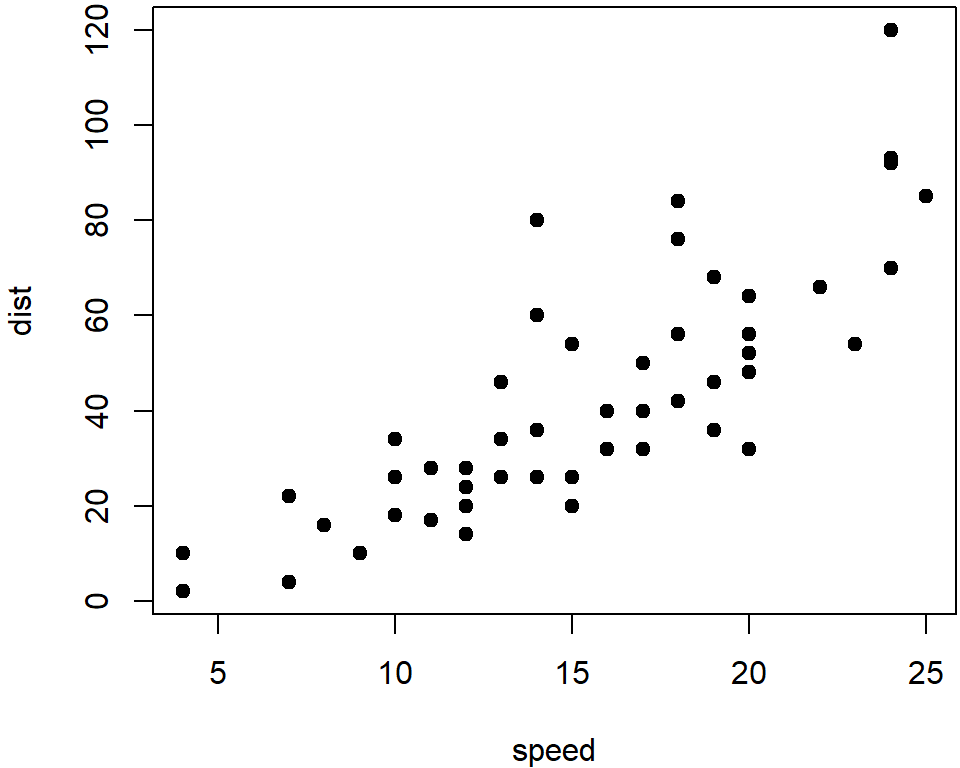

The figure on the left-hand side shows the `cars` data.

| orden | precio | unidades |
| --- | --- | --- |
| 1 | 10 | 100 |

- **Coste** Coste medio de compra de las acciones
- **Valor** Valor de la cartera al momento actual
- **Neto** Precio que marca el punto de ruptura

Usamos el termino precio neto frente al mas correcto Precio Medio para indicar cual es el precio de **venta** que me ofrece un beneficio global de 0. Dicho de otro modo, el precio minimo al que puedo deshacer la posicion sin perder dinero.

Supongamos que hago una primera operacion de compra:

La operacion es basica, logicamente si he comprado **n** unidades a un precio **p**, si las vendo por debajo de ese precio pierdo dinero, si lo vendo por encima de ese precio, gano dinero

Ahora supongamos que vendo 5 de mis unidades a 120

Para evitar esto, introducimos el concepto de **regularizacion**

ESte es un registro que me marca el punto a partir del cual considerar las operaciones posteriores. Tipicamente, y desde el punto de vista contable, se genera un registro de regularizacion cada 1/1